# Week 1 - Information theory

## Paper

Sims, C.R. (2016) Rate-distortion theory and human perception http://dx.doi.org/10.1016/j.cognition/2016.03.020

## Information theory

This week we get an introduction to information theory, courtesy of Chris Sims, placed in the context of rate-distortion theory of human perception.

We start with some definitions:

### Definitions

- a **random variable** is a variable which can take on one of a (potentially infinite) set of values
- the potential values of a random variable are its **alphabet**
- each value in the alphabet has an associated **probability**
- given alphabets exhaustively cover possible values for the random variable, their associated probabilities sum to 1
- the **surprise** we experience on observing the actual value of a random variable is characterised by the negative log of the probability associated with that outcome (negative log likelihood)

We know that all probabilities are in the interval $[0, 1]$, meaning the values of surprise are in the interval $[0, \infty]$, with an inverse relationship between probability and surprise.

### Entropy

Entropy is (weighted) **average surprise**. So for an idealised fair coin, which has two possible outcomes (each with $P(x)=.5$ and $-\log P(x)=.693$), so the entropy is also $.693$, because all outcomes are equally likely.

Similarly, with an idealised fair 6-sided die, we get the surprise for each outcome =$-log \frac{1}{6}$, or $1.792$.

This should make sense, because predicting which of the six faces on the die will appear is inherently more difficult than prediciting which of the two faces of the coin will appear, hence each specific outcome for the die is more surprising, and hence the average surprise is higher.

##### Unbalanced probabilities

Consider next a class of students. Some do very well (A grade), some do very poorly (C), and most do kinda okay (B):

```r
nKids <- 30 # class size

kids <- data.frame(id = 1:nKids,
                   ability = rnorm(nKids),
                   performance = rnorm(nKids),
                   grade = "A")

# correlate abilty and performance
kids$performance <- kids$performance + .3 * kids$ability

# assign grades
levels(kids$grade) <- LETTERS[1:3]
kids$grade[kids$performance < 1] <- factor("B")
kids$grade[kids$performance < -1] <- factor("C")

grades <- table(kids$grade)
grades
```

```
##
##  A  B  C
##  2 21  7
```

Grade can be our random variable, which we can use the empirical measurement of to determine the probabilities:

```r
grades <- rbind(grades, table(kids$grade) / nKids)
grades <- as.data.frame(t(grades))
colnames(grades) <- c("n", "p")
grades
```

|  | n | p |
| --- | --- | --- |
| A | 2 | 0.06666667 |
| B | 21 | 0.70000000 |
| C | 7 | 0.23333333 |

We can thus calculate that the mean surprise as the negative log of each probability:

```r
grades <- cbind(grades, data.frame(s = -log(grades$p)))
grades
```

|  | n | p | s |
| --- | --- | --- | --- |
| A | 2 | 0.06666667 | 2.7080502 |
| B | 21 | 0.70000000 | 0.3566749 |
| C | 7 | 0.23333333 | 1.4552872 |

and therefore the mean:

```r
mean(grades$s)
```

```
## [1] 1.506671
```

The entropy ($H$), however, is not simply the mean surprise, but it’s the weighted mean surprise: we have to multiply each of our surprise values by the probability that we will encounter that value:

$$H(x) = -\sum_i P(x_i) \log P(x_i)$$

```r
sum(grades$s * grades$p)
```

```
## [1] 0.7697762
```

### Units of entropy

So far we’ve been using the natural logarithm (R’s default), giving us entropy values in ’nat’s. To get the entropy in the more standard ’bit’s, we need to use $\log _2$.

```r
grades$sb <- -log2(grades$p)
sum(grades$sb * grades$p)
```

```
## [1] 1.110552
```

### Measurement and prediction

So far we’ve just been noting our surprise at any given outcome, and using these observations to determine the average surprise we could expect from the next (unknown) outcome (i.e. entropy).

We can also use this framework to describe how we use one variable to reduce the uncertainty of another. When we produced our class full of kids, we gave each one an *ability* score and a *performance* score, with a moderate correlation between them (.3). We then used the *performance* to assign *grades*, with performance > 1sd being “A”, (-1,1) being “B”, and < -1 being “C”.

The distribution of grades thus predicts *ability*, but not completely. Some kids given grade “C” have a higher ability than some given grade “A”, for example:

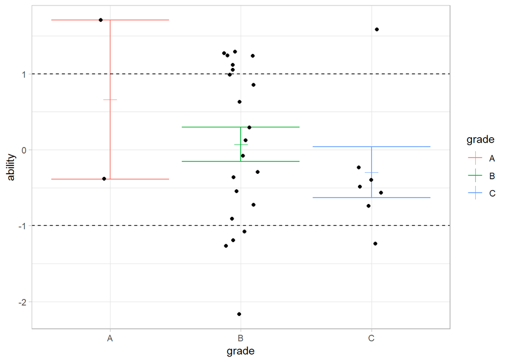

```r
ggplot(kids, aes(x = grade, y = ability, color = grade)) +
  stat_summary(geom = "point", fun.y = mean, size = 4, shape = 3) +
  stat_summary(geom = "errorbar", fun.data = mean_se) +
  geom_point(position = position_jitter(.15), color = "black") +
  geom_hline(yintercept = -1, linetype = "dashed") +
  geom_hline(yintercept = 1, linetype = "dashed") +
  theme_light()
```

We can use information theory to quantify the effectiveness with which the assigned grade conveys information about the kid’s ability score. The key observation is that some amount of information in the source (*ability score*) is present in measurement (*grade*, but we could also use *performance*).

The quantity of information shared between the measurement and source is known as **mutual information**, and is formulated as the information in the source minus the conditional entropy of the measurement:

$$I(x,y) = H(x) - H(x|y)$$

$$I(x,y) = \sum _i \sum _j P(y_i|x_i)P(x_i) \log \frac{P(y_j|x_i)}{P(y_i)}$$
It looks complicated. It’s simpler when we understand conditional entropy:
$$H(x|y)=\sum _j P(y_j)H(x|y=y_j)
\\
=-\sum _j P(y_i) \sum _i P(x_i|y_j) \log P(x_i|y_i)$$

which quantifies the mean surprise we have in discovering that the source value is actually ‘$x$’ (over all possible values of our measurement variable). The mutual information is therefore calculated by multiplying the entropy of $x$ at each value in the alphabet of $y$, weighted by the assocated probability of that value.